# R Notebook

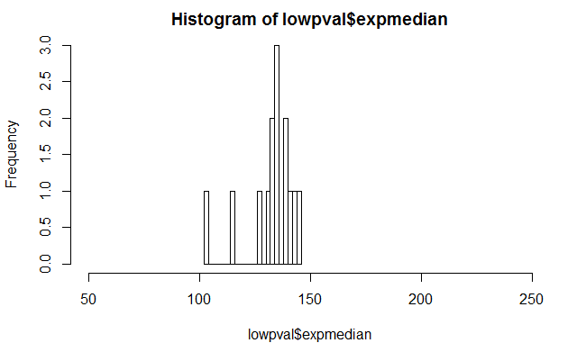

```r
hist(lowpval$expmedian,breaks=20, xlim=range(50:250))
```

Действительно ли столь невероятно получить так мало маленьких p-value? Да. А после пересчета на 520 новых итераций? Все еще да

```r
dbinom(11, size=1000, prob=0.05)+dbinom(10, size=1000, prob=0.05)+dbinom(9, size=1000, prob=0.05)+dbinom(8, size=1000, prob=0.05)
```

```
[1] 1.355392e-11
```

```r
dbinom(14, size=520, prob=0.05)+dbinom(13, size=520, prob=0.05)+dbinom(12, size=520, prob=0.05)+dbinom(11, size=520, prob=0.05)+dbinom(10, size=520, prob=0.05)
```

```
[1] 0.006437043
```

Как выглядит распределение медианной статистики для сэмплов с хорошими pvalue по срединной статистике?

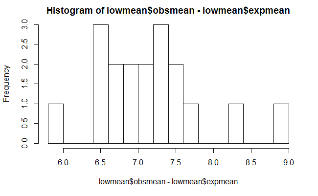

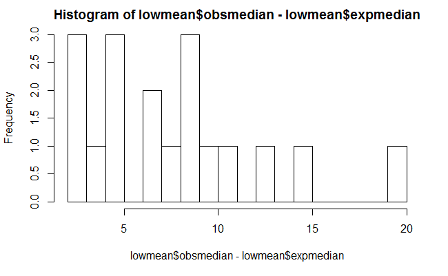

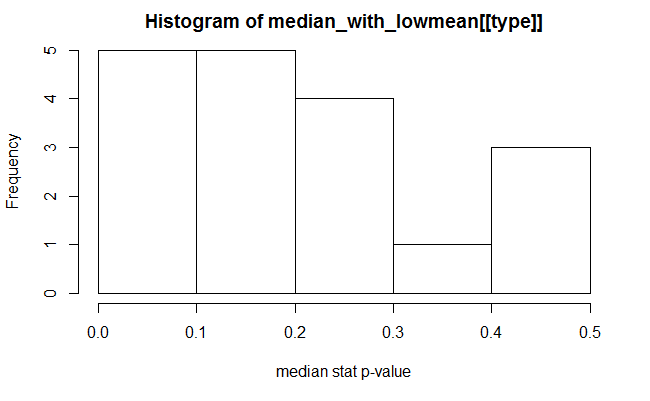

```r
median_for_mean<- function(type = "env", threshold = 0.05){
  mycsv<-read.csv("C:/Users/weidewind/Documents/CMD/Coevolution/Influenza/environment_or_epistasis/sanityCheck/h1_allnew_iterations_fdr")
  newdat<- mycsv[mycsv$restr==100 & mycsv$stat == "mean_stat",]
  lowmean <-newdat[newdat[[type]]<threshold,]
  hist(lowmean$obsmean-lowmean$expmean,breaks=20)
  hist(lowmean$obsmedian-lowmean$expmedian,breaks=20)
  folders = mycsv[mycsv$restr==100 & mycsv$stat == "mean_stat" & mycsv[[type]]<threshold, 1]
  median_with_lowmean <- mycsv[mycsv$folder %in% folders,]
  median_with_lowmean <- median_with_lowmean[median_with_lowmean$restr==100 & median_with_lowmean$stat == "median_stat",]
  median_with_lowmean
  hist(median_with_lowmean[[type]], xlab = "median stat p-value")
}
median_for_mean(type="env")
```

А вот это, извините, распределение pvalue для фейковых сайтов! (“распределение” для одного сайта - это, на самом деле, pvalue для всех сайтов на этом узле (по одной штуке на каждый сайт и каждый maxdepth) )

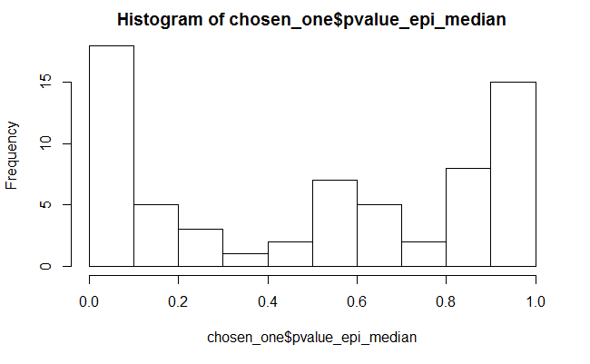

```r
sites<-read.csv("C:/Users/weidewind/Documents/CMD/Coevolution/Influenza/environment_or_epistasis/sanityCheck/h1_sites_fdr")
chosen_one <- sites[sites$node == "INTNODE2429" & sites$depth == 50,] # INTNODE2429 2434 2406
hist(chosen_one$pvalue_epi_median)
```

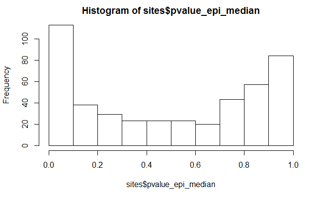

```r
hist(sites$pvalue_epi_median)
```

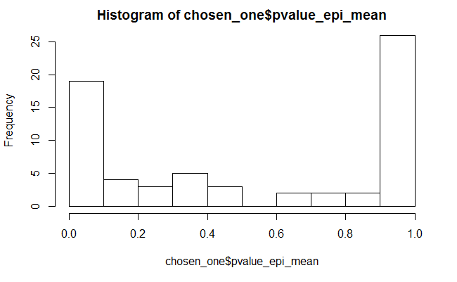

```r
hist(chosen_one$pvalue_epi_mean)
```

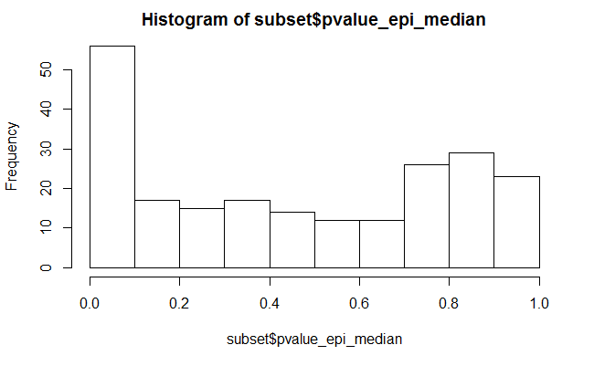

```r
subset <- sites[sites$mutations >3,]
hist(subset$pvalue_epi_median)
```

Сравним распределение статистики для одного узла, получающееся на симуляциях и на фейковых датасетах. Да, они разные. Добавили еще фейковых сэмплов, и добавили значения статистики в файл, но суть осталась прежней (h1_sites_fdr_with_stats тоже порожден grep_site_fdr.pl) Вытащили из случайного места симуляционное распределение статистики для узла (они все одинаковы. должны быть.)

```r
sites<-read.csv("C:/Users/weidewind/Documents/CMD/Coevolution/Influenza/environment_or_epistasis/sanityCheck/h1_sites_fdr_with_stats")
chosen_one <- sites[sites$node == "INTNODE2429" & sites$site == 238 & sites$depth == 50,]
chosen_one
```

|  | depth | site | node | mutations | maxlength | pvalue_epistasis_median | pvalue_epistasis_mean | pvalue_environment_median | pvalue_environment_mean | obs_median | exp_median | obs_mean | exp_mean |
| --- | --- | --- | --- | --- | --- | --- | --- | --- | --- | --- | --- | --- | --- |
| 462 | 50 | 238 | INTNODE2429 | 4 | 88 | 0.7046 | 0.9552 | 0.3102 | 0.0448 | 53.50 | 46 | 57.50000 | 43.0451127819549 |
| 1728 | 50 | 238 | INTNODE2429 | 6 | 87 | 0.7998 | 0.7800 | 0.2010 | 0.2200 | 63.75 | 52 | 58.08333 | 50.4624838292367 |
| 2085 | 50 | 238 | INTNODE2429 | 4 | 59 | 0.6772 | 0.3852 | 0.3236 | 0.6148 | 52.75 | 46 | 41.37500 | 40.8545816733068 |
| 2804 | 50 | 238 | INTNODE2429 | 5 | 140 | 0.2462 | 0.1754 | 0.7688 | 0.8246 | 68.50 | 72 | 74.40000 | 78.5446009389671 |
| 2955 | 50 | 238 | INTNODE2429 | 20 | 193 | 0.5044 | 0.2424 | 0.4972 | 0.7576 | 163.25 | 161 | 136.72500 | 139.251270553064 |
| 4508 | 50 | 238 | INTNODE2429 | 13 | 174 | 0.979 | 0.9866 | 0.0214 | 0.0134 | 129.00 | 94 | 116.80769 | 98.4733408961997 |
| 5562 | 50 | 238 | INTNODE2429 | 4 | 88 | 0.422 | 0.1752 | 0.6114 | 0.8248 | 40.50 | 40 | 39.87500 | 44.063245823389 |
| 5957 | 50 | 238 | INTNODE2429 | 2 | 88 | 0.0226 | 0.0014 | 0.9780 | 0.9986 | 22.00 | 50 | 22.00000 | 47.7540106951872 |
| 6130 | 50 | 238 | INTNODE2429 | 3 | 88 | 0.5456 | 0.7866 | 0.4758 | 0.2134 | 58.00 | 55 | 61.50000 | 53.7605042016807 |
| 7361 | 50 | 238 | INTNODE2429 | 4 | 88 | 0.4748 | 0.7186 | 0.5262 | 0.2814 | 43.00 | 38 | 43.00000 | 39.677018633540458.75 |

[output cut: 2 more lines]

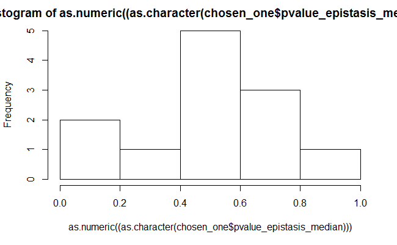

```r
hist(as.numeric((as.character(chosen_one$pvalue_epistasis_median))))
```

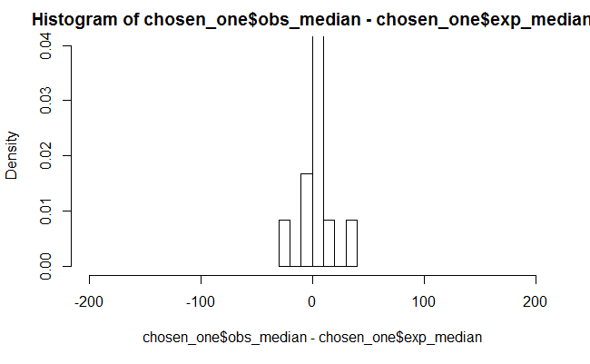

```r
hist(chosen_one$obs_median-chosen_one$exp_median, freq=FALSE, ylim = range(0,0.04), xlim = range(-200,200)) # fake distribution
```

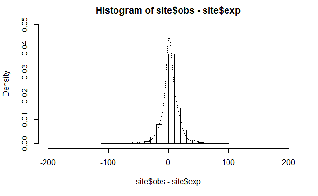

```r
site<-read.csv("C:/Users/weidewind/Documents/CMD/Coevolution/Influenza/environment_or_epistasis/sanityCheck/2429_iterations.txt")
hist(site$obs-site$exp, freq=FALSE, ylim = range(0,0.05), xlim = range(-200,200)) # simulation distribution
#lines(density(site$obs-site$exp))             # add a density estimate with defaults
lines(density(site$obs-site$exp, adjust=2), lty="dotted")   # add another "smoother" density
```

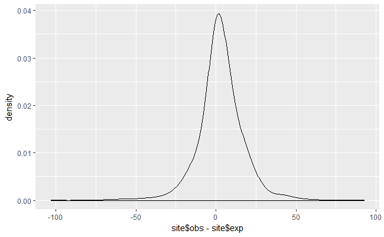

```r
#install.packages("ggplot2")
library(ggplot2)
dataset = data.frame(site$obs-site$exp)
#+ geom_histogram(aes(y = ..density..))
ggplot(dataset, aes(x = site$obs-site$exp))  + geom_density(adjust = 3)
```

```r
sites<-read.csv("C:/Users/weidewind/Documents/CMD/Coevolution/Influenza/environment_or_epistasis/sanityCheck/h1_sites_fdr_with_stats")
velocity <- sapply(sites$mutations, function (e){
  if (is.na(e)) {"unknown"}
  else if(e <= 3) {"slow-evolving sites"}
  else{"fast-evolving sites"}
} )
gr <- rep("simulations (equal \nevolution rate for all sites)", length(velocity))
sites <- data.frame(sites, velocity,gr)
# & sites$mutations <= 3,
filtered = sites[sites$depth == 50 & sites$velocity != "unknown", ]
head(filtered, 10)
```

|  | depth | site | node | mutations | maxlength | pvalue_epistasis_median | pvalue_epistasis_mean | pvalue_environment_median | pvalue_environment_mean | obs_median | exp_median | obs_mean | exp_mean | velocity | gr |
| --- | --- | --- | --- | --- | --- | --- | --- | --- | --- | --- | --- | --- | --- | --- | --- |
| 83 | 50 | 227 | INTNODE2423 | 1 | 124 | 0.652706552706553 | 0.6729345 | 0.36096866 | 0.32706553 | 156.25 | 147 | 156.25000 | 136.28793130612969.5 | slow-evolving sites | simulations (equal \nevolution rate for all sites) |
| 85 | 50 | 211 | INTNODE2429 | 3 | 230 | 0.9338 | 1.0000000 | 0.06840000 | 0.00000000 | 208.00 | 186 | 208.33333 | 168.186025943396 | slow-evolving sites | simulations (equal \nevolution rate for all sites) |
| 86 | 50 | 142 | INTNODE2401 | 6 | 66 | 0.770908363345338 | 0.9753902 | 0.23169268 | 0.02460984 | 55.25 | 53 | 53.66667 | 47.6875 | fast-evolving sites | simulations (equal \nevolution rate for all sites) |
| 87 | 50 | 466 | INTNODE2415 | 1 | 175 | 0.898619704902427 | 0.9662066 | 0.11518325 | 0.03379343 | 152.00 | 133 | 152.00000 | 125.613967022308 | slow-evolving sites | simulations (equal \nevolution rate for all sites) |
| 88 | 50 | 299 | INTNODE2298 | 1 | 52 | 0.148730350665054 | 0.1459089 | 0.91797662 | 0.85409109 | 29.00 | 32 | 29.00000 | 32.2366040361865 | slow-evolving sites | simulations (equal \nevolution rate for all sites) |
| 89 | 50 | 101 | INTNODE2433 | 5 | 264 | 0.820583794665325 | 0.9227479 | 0.18822345 | 0.07725214 | 241.00 | 220 | 233.20000 | 197.985603224878 | fast-evolving sites | simulations (equal \nevolution rate for all sites) |
| 90 | 50 | 142 | INTNODE2433 | 8 | 170 | 0.916708605938601 | 0.8298943 | 0.08379467 | 0.17010569 | 129.75 | 98 | 121.18750 | 96.4157667386609 | fast-evolving sites | simulations (equal \nevolution rate for all sites) |
| 91 | 50 | 476 | INTNODE2434 | 4 | 269 | 0.6556 | 0.9904000 | 0.34440000 | 0.00960000 | 233.25 | 225 | 227.37500 | 201.887788533135 | fast-evolving sites | simulations (equal \nevolution rate for all sites) |
| 92 | 50 | 111 | INTNODE2298 | 6 | 52 | 0.346835953244659 | 0.8166062 | 0.76239420 | 0.18339379 | 30.00 | 32 | 31.66667 | 32.0180084745763 | fast-evolving sites | simulations (equal \nevolution rate for all sites) |
| 93 | 50 | 176 | INTNODE2401 | 15 | 103 | 0.767707082833133 | 0.5044018 | 0.26170468 | 0.49559824 | 78.00 | 76 | 66.16667 | 67.0248053392659 | fast-evolving sites | simulations (equal \nevolution rate for all sites) |

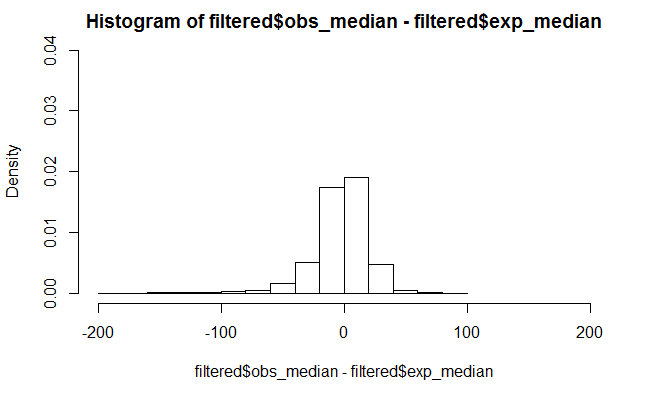

```r
hist(filtered$obs_median-filtered$exp_median, freq=FALSE, ylim = range(0,0.04), xlim = range(-200,200)) # fake distribution
```

```r
dat = filtered$obs_median-filtered$exp_median
dataset1 = data.frame(dat)
length(dataset1$velocity)
```

```
[1] 0
```

```r
length(dataset1)
```

```
[1] 1
```

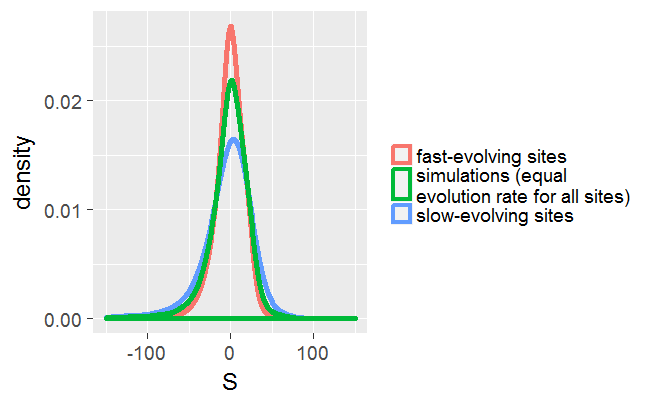

```r
ggplot(dataset1, aes(x = dat))  + geom_density(adjust = 3, aes(x = dat, color = filtered$velocity),size=2) +geom_density(aes(x = dat, color = filtered$gr), adjust = 3,size=2) + labs(x="S", color = "") + scale_x_continuous(limits = c(-150, 150)) + theme_grey(base_size = 18)
```

```r
#fast = sites[sites$depth == 50 & sites$mutations > 3,]
#head(fast)
#hist(fast$obs_median-fast$exp_median, freq=FALSE, ylim = range(0,0.04), xlim = range(-200,200)) # fake distribution
#dat2 = fast$obs_median-fast$exp_median
#dataset2 = data.frame(dat2)
#ggplot(dataset2, aes(x = dat2))  + geom_density(adjust = 3)
```

А действительно ли наш shuffler разбрасывает мутации пропорционально длине веток? (shuffler_check.pl) Ага.

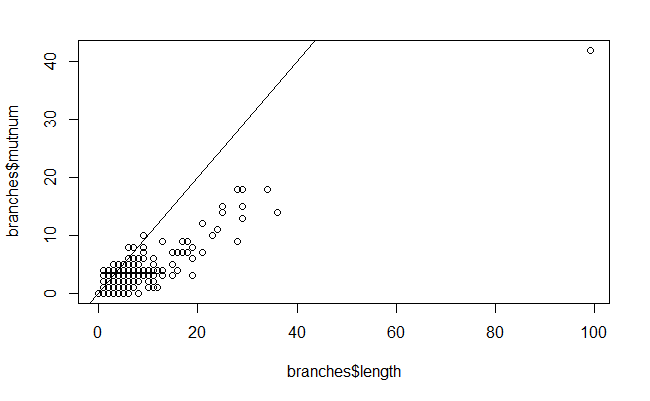

```r
branches<-read.csv("C:/Users/weidewind/Documents/CMD/Coevolution/Influenza/environment_or_epistasis/sanityCheck/shuffler_sanity_check_shuffled.csv")
plot(branches$length, branches$mutnum)
abline(0,1)
```

```r
branches[branches$length > 80,]
```

|  | nodename | length | mutnum | bkgrmutnum |
| --- | --- | --- | --- | --- |
| 1773 | AAD17229\|USA\|1918 | 99 | 42 | 53 |

```r
sum(branches$mutnum)
```

```
[1] 1588
```

```r
sum(branches$bkgrmutnum)
```

```
[1] 2234
```

```r
sum(branches$length)
```

```
[1] 3872
```

```r
branches[branches$length != branches$bkgrmutnum+branches$mutnum,]
```

|  | nodename | length | mutnum | bkgrmutnum |
| --- | --- | --- | --- | --- |
| 1 | ABD77972\|New_Zealand\|2000 | 1 | 1 | 1 |
| 5 | INTNODE1436 | 7 | 3 | 7 |
| 9 | INTNODE2428 | 25 | 14 | 17 |
| 11 | INTNODE2433 | 5 | 3 | 3 |
| 19 | INTNODE1254 | 1 | 0 | 0 |
| 21 | ACM51316\|USA\|2008 | 1 | 0 | 0 |
| 22 | INTNODE1781 | 1 | 1 | 1 |
| 24 | ACI32718\|Germany\|2005 | 5 | 0 | 3 |
| 26 | ABV29568\|USA\|2007 | 1 | 1 | 1 |
| 27 | INTNODE1978 | 1 | 1 | 1 |

[output cut: 861 more lines]

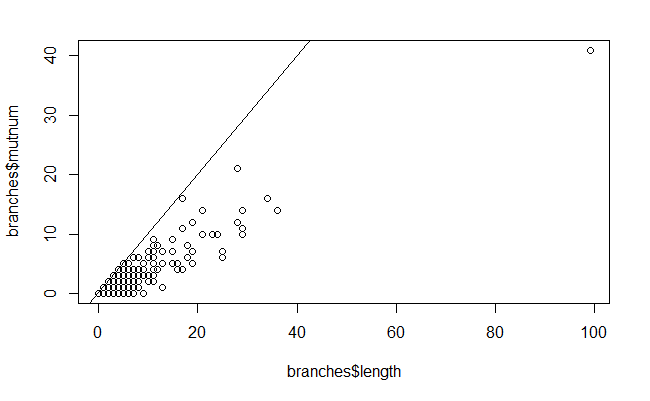

```r
branches<-read.csv("C:/Users/weidewind/Documents/CMD/Coevolution/Influenza/environment_or_epistasis/sanityCheck/shuffler_sanity_check_realdata.csv")
plot(branches$length, branches$mutnum)
abline(0,1)
```

```r
sum(branches$mutnum)
```

```
[1] 1588
```

```r
sum(branches$bkgrmutnum)
```

```
[1] 2234
```

```r
sum(branches$length)
```

```
[1] 3872
```

```r
branches[branches$length != branches$bkgrmutnum+branches$mutnum,]
```

|  | nodename | length | mutnum | bkgrmutnum |
| --- | --- | --- | --- | --- |
| 9 | INTNODE2428 | 25 | 7 | 17 |
| 233 | INTNODE1365 | 4 | 2 | 1 |
| 338 | ADA71154\|Russia\|2009 | 8 | 4 | 2 |
| 353 | ACQ90234\|Australia\|2008 | 21 | 10 | 4 |
| 406 | ABD61735\|USA\|1950 | 8 | 4 | 3 |
| 407 | ADA71164\|Russia\|2009 | 11 | 9 | 1 |
| 422 | ABS76427\|Thailand\|2000 | 5 | 2 | 2 |
| 495 | BAI44861\|Thailand\|2008 | 8 | 4 | 3 |
| 561 | BAI44859\|Thailand\|2008 | 2 | 1 | 0 |
| 570 | ABU50570\|USA\|2006 | 2 | 1 | 0 |

[output cut: 26 more lines]

```r
branches[branches$nodename == "INTNODE2435",]
```

|  | nodename | length | mutnum | bkgrmutnum |
| --- | --- | --- | --- | --- |
| 2286 | INTNODE2435 | 11 | 8 | 3 |

```r
branches<-read.csv("C:/Users/weidewind/Documents/CMD/Coevolution/Influenza/environment_or_epistasis/sanityCheck/shuffler_check_real_realdata")
sum(branches$mutnum)
```

```
[1] 1588
```

```r
sum(branches$bkgrmutnum)
```

```
[1] 2234
```

```r
sum(branches$length)
```

```
[1] 3872
```

Возможно, наши безумные распределения pvalue получаются так: в реальных данных число узлов в группе намного меньше, чем в симуляции (если мы говорим об одном сайтоузле, то в реальных данных наблюдение одно, а в симуляции их может быть много - сколько сайтов мутировало на этом узле, столько у нас и наблюдений). В игру вступает ЦПТ: в симуляциях уходы всегда гораздо ближе к середине просто из-да того, что их больше! Как проверить? на длинные ветки должно попадать больше родительских мутаций, стало быть, для них неравномерность pvalue должна быть сильнее выражена.

```r
sites<-read.csv("C:/Users/weidewind/Documents/CMD/Coevolution/Influenza/environment_or_epistasis/sanityCheck/h1_sites_fdr_with_stats", stringsAsFactors=FALSE)
#grep("[)(,)](.*:[0-9]+)", c("abc", "def", "cba a", "aa"), perl=TRUE, value=TRUE)
con <- file("C:/Users/weidewind/Documents/CMD/Coevolution/Influenza/Kryazhimsky11/h1.l.r.newick")
tree <- readLines(con)
library(stringr)
intnodes <- str_extract_all(tree, "INTNODE[0-9]+:[0-9]+")[[1]]
spli <- str_split(intnodes, ":")
spli[[5]][2]
```

```
[1] "28"
```

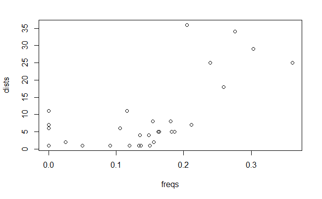

```r
node <- sapply(spli, function(e){
  as.character(e[1])
})
dists <- sapply(spli, function(e){
  as.numeric(e[2])
})
dist_df <-data.frame(node,dists, stringsAsFactors=FALSE)
#head(dist_df)
#head(sites)
merged <-merge (sites, dist_df, by = "node", stringsAsFactors=FALSE)
merged_clean <- merged[merged$dists >0 & merged$depth == 50,]
#head(merged,10)
nodes <- unique(merged_clean$node)
freqs<- sapply (nodes, function(e){
  tail <- nrow(merged_clean[merged_clean$node == e & merged_clean$pvalue_epistasis_median < 0.1,])
  all<- nrow(merged_clean[merged_clean$node == e,])
  #print(tail)
  #print(all)
  tail/all
})
dists <- sapply(names(freqs), function(e){
  dist_df[dist_df$node == e, "dists"]
})
plot(freqs,dists)
```

```r
#chosen_one <- sites[sites$node == "INTNODE2429",] # INTNODE2429 2434 2406
#nrow(chosen_one[chosen_one$pvalue_epi_median < 0.1,])/nrow(chosen_one)
```

Теперь каждое поддерево в симуляции приравнивается к отедбльной итерации. Число уходов пока никак не контролируем. 250 итераций, 40 фейков (output/fake_new_iterations/nsyn/maxpath_not_subtracted/no_mutnum_check) Идеально. Эти горки недвусмысленно намекают, что нужно контролировать число уходов.

```r
sites<-read.csv("C:/Users/weidewind/Documents/CMD/Coevolution/Influenza/environment_or_epistasis/sanityCheck/h1_sites_fdr_with_stats_clt_no_mutnum_check", stringsAsFactors=FALSE, colClasses = c("pvalue_epistasis_median" = "numeric"))
head(sites, 10)
```

|  | depth | site | node | mutations | maxlength | pvalue_epistasis_median | pvalue_epistasis_mean | pvalue_environment_median | pvalue_environment_mean | obs_median | exp_median | obs_mean | exp_mean |
| --- | --- | --- | --- | --- | --- | --- | --- | --- | --- | --- | --- | --- | --- |
| 1 | 100 | 169 | INTNODE2434 | 3 | 103 | 0.8249601 | 0.7603668 | 0.19856459 | 0.2396332 | 83.5 | 62 | 83.83333 | 54.80582 |
| 2 | 100 | 424 | INTNODE2429 | 3 | 230 | 0.3942857 | 0.7261905 | 0.61190476 | 0.2738095 | 184.0 | 186 | 190.16667 | 168.33414 |
| 3 | 100 | 113 | INTNODE2434 | 3 | 136 | 0.8249601 | 0.8094099 | 0.19856459 | 0.1905901 | 112.5 | 91 | 115.83333 | 83.06698 |
| 4 | 100 | 150 | INTNODE2429 | 3 | 169 | 0.9866667 | 0.9800000 | 0.01809524 | 0.0200000 | 134.5 | 87 | 135.33333 | 88.36557 |
| 5 | 100 | 125 | INTNODE2428 | 3 | 205 | 0.7151741 | 0.8128109 | 0.30970149 | 0.1871891 | 179.5 | 163 | 175.00000 | 151.27647 |
| 6 | 100 | 461 | INTNODE2425 | 1 | 191 | 0.2070796 | 0.3132743 | 0.79469027 | 0.6867257 | 131.5 | 148 | 131.50000 | 135.64080 |
| 7 | 100 | 97 | INTNODE2435 | 5 | 305 | 0.2269022 | 0.3573370 | 0.77581522 | 0.6426630 | 239.0 | 260 | 232.50000 | 229.13182 |
| 8 | 100 | 218 | INTNODE2435 | 5 | 305 | 0.5285326 | 0.8355978 | 0.47961957 | 0.1644022 | 264.0 | 259 | 270.80000 | 227.97604 |
| 9 | 100 | 467 | INTNODE2434 | 9 | 269 | 0.4924242 | 0.5618022 | 0.51634769 | 0.4381978 | 205.5 | 203 | 204.66667 | 189.55662 |
| 10 | 100 | 99 | INTNODE2428 | 9 | 205 | 0.3992537 | 0.4608209 | 0.61007463 | 0.5391791 | 161.0 | 163 | 157.27778 | 151.28606 |

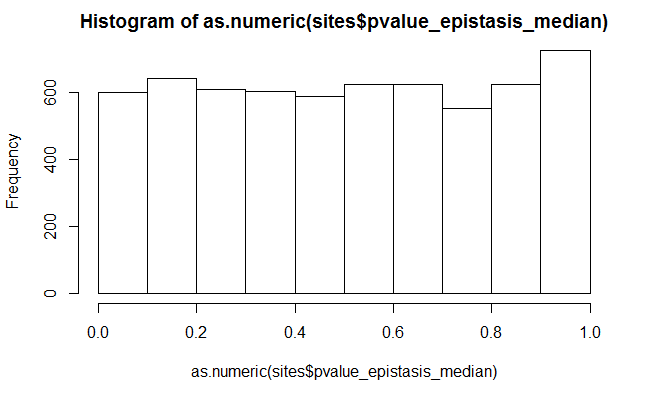

```r
#chosen_one <- sites[sites$node == "INTNODE2429" & sites$depth == 50,] # INTNODE2429 2434 2406
#hist(chosen_one$pvalue_epi_median)
hist(as.numeric(sites$pvalue_epistasis_median))
#hist(chosen_one$pvalue_epi_mean)
opar=par(ps=18)
```

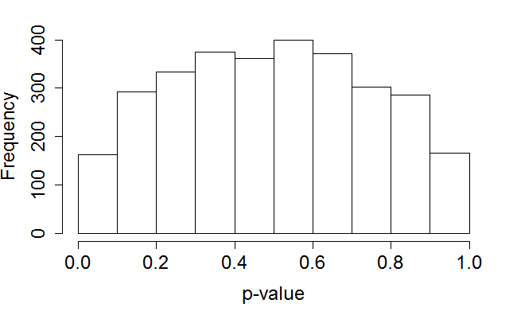

```r
fast_subset <- sites[sites$mutations > 3,]
#main="Acclimatization p-values for fast evolving simulated sites"
hist(fast_subset$pvalue_epistasis_median, main = "", xlab="p-value")
```

```r
opar
```

```
$ps
[1] 12
```

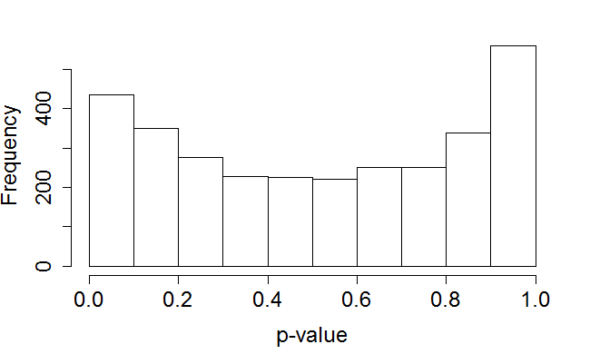

```r
slow_subset <- sites[sites$mutations <= 3,]
hist(slow_subset$pvalue_epistasis_median, main = "", xlab="p-value")
```

А тут число уходов не должно отличаться от реального больше, чем на 20% (output/fake_new_iterations/nsyn/maxpath_not_subtracted/mutnum_check)

```r
all_sites<-read.csv("C:/Users/weidewind/Documents/CMD/Coevolution/Influenza/environment_or_epistasis/sanityCheck/h1_sites_fdr_with_stats_mutnum_control", stringsAsFactors=FALSE, colClasses = c("pvalue_epistasis_median" = "numeric"))
sites <- all_sites[all_sites$iterations > 50, ]
nrow(all_sites) - nrow(sites)
```

```
[1] 1792
```

```r
head(sites, 10)
```

|  | depth | site | node | mutations | maxlength | pvalue_epistasis_median | pvalue_epistasis_mean | pvalue_environment_median | pvalue_environment_mean | obs_median | exp_median | obs_mean | exp_mean | iterations |
| --- | --- | --- | --- | --- | --- | --- | --- | --- | --- | --- | --- | --- | --- | --- |
| 1 | 100 | 197 | INTNODE2428 | 1 | 205 | 0.02325581 | 0.02325581 | 0.9767442 | 0.9767442 | 43.50 | 163 | 43.50000 | 152.38750 | 258 |
| 2 | 100 | 452 | INTNODE2434 | 3 | 269 | 0.41290323 | 0.18064516 | 0.6000000 | 0.8193548 | 225.50 | 225 | 185.50000 | 202.30467 | 310 |
| 3 | 100 | 85 | INTNODE2434 | 4 | 269 | 0.24555160 | 0.20996441 | 0.7544484 | 0.7900356 | 208.50 | 224 | 187.12500 | 202.59366 | 281 |
| 5 | 100 | 97 | INTNODE2401 | 3 | 103 | 0.15789474 | 0.34210526 | 0.8421053 | 0.6578947 | 53.00 | 77 | 60.33333 | 67.54380 | 228 |
| 6 | 100 | 197 | INTNODE2434 | 1 | 127 | 0.29922780 | 0.23938224 | 0.8069498 | 0.8667954 | 51.50 | 65 | 51.50000 | 66.14842 | 518 |
| 7 | 100 | 60 | INTNODE2434 | 1 | 127 | 0.75096525 | 0.65250965 | 0.2606178 | 0.3474903 | 113.50 | 91 | 113.50000 | 82.51938 | 518 |
| 8 | 100 | 398 | INTNODE2434 | 4 | 127 | 0.84341637 | 0.60142349 | 0.1672598 | 0.3985765 | 93.25 | 72 | 88.50000 | 71.30657 | 281 |
| 9 | 100 | 467 | INTNODE2429 | 13 | 230 | 0.35714286 | 0.50793651 | 0.6746032 | 0.4920635 | 188.00 | 188 | 176.73077 | 173.16573 | 126 |
| 11 | 100 | 219 | INTNODE2401 | 1 | 103 | 0.68150685 | 0.67465753 | 0.3458904 | 0.3253425 | 81.00 | 77 | 81.00000 | 67.47460 | 292 |
| 12 | 100 | 232 | INTNODE2406 | 3 | 143 | 0.83534137 | 0.65060241 | 0.1967871 | 0.3493976 | 120.00 | 103 | 105.33333 | 99.34738 | 249 |

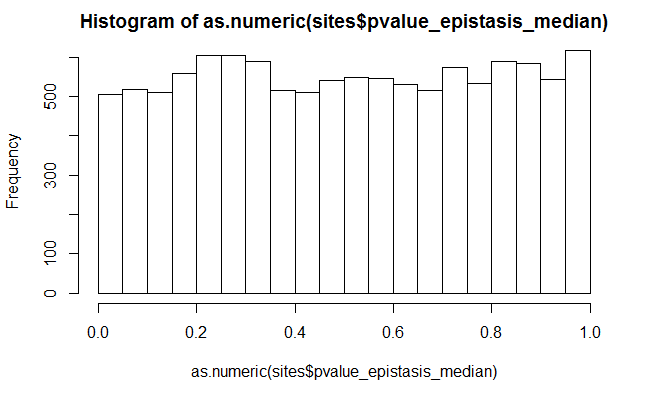

```r
#chosen_one <- sites[sites$node == "INTNODE2429" & sites$depth == 50,] # INTNODE2429 2434 2406
#hist(chosen_one$pvalue_epi_median)
hist(as.numeric(sites$pvalue_epistasis_median))
#hist(chosen_one$pvalue_epi_mean)
fast_subset <- sites[sites$mutations > 3,]
opar=par(ps=18)
```

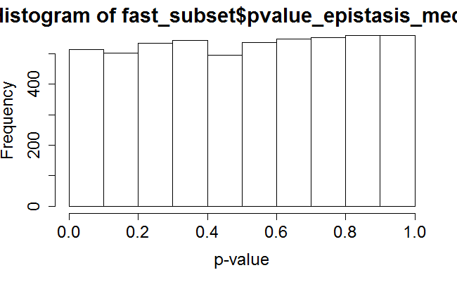

```r
hist(fast_subset$pvalue_epistasis_median, xlab="p-value")
```

```r
opar
```

```
$ps
[1] 12
```

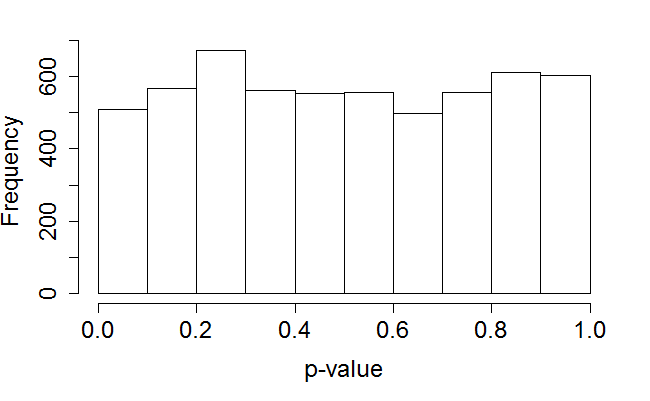

```r
slow_subset <- sites[sites$mutations <= 3,]
hist(slow_subset$pvalue_epistasis_median, main="", xlab="p-value")
```

```r
all_sites<-read.csv("C:/Users/weidewind/Documents/CMD/Coevolution/Influenza/environment_or_epistasis/sanityCheck/h1_sites_fdr_with_stats_mutnum_control", stringsAsFactors=FALSE, colClasses = c("pvalue_epistasis_median" = "numeric"))
sites <- all_sites[all_sites$iterations > 50, ]
nrow(all_sites) - nrow(sites)
```

```
[1] 1792
```

```r
head(sites, 10)
```

|  | depth | site | node | mutations | maxlength | pvalue_epistasis_median | pvalue_epistasis_mean | pvalue_environment_median | pvalue_environment_mean | obs_median | exp_median | obs_mean | exp_mean | iterations |
| --- | --- | --- | --- | --- | --- | --- | --- | --- | --- | --- | --- | --- | --- | --- |
| 1 | 100 | 197 | INTNODE2428 | 1 | 205 | 0.02325581 | 0.02325581 | 0.9767442 | 0.9767442 | 43.50 | 163 | 43.50000 | 152.38750 | 258 |
| 2 | 100 | 452 | INTNODE2434 | 3 | 269 | 0.41290323 | 0.18064516 | 0.6000000 | 0.8193548 | 225.50 | 225 | 185.50000 | 202.30467 | 310 |
| 3 | 100 | 85 | INTNODE2434 | 4 | 269 | 0.24555160 | 0.20996441 | 0.7544484 | 0.7900356 | 208.50 | 224 | 187.12500 | 202.59366 | 281 |
| 5 | 100 | 97 | INTNODE2401 | 3 | 103 | 0.15789474 | 0.34210526 | 0.8421053 | 0.6578947 | 53.00 | 77 | 60.33333 | 67.54380 | 228 |
| 6 | 100 | 197 | INTNODE2434 | 1 | 127 | 0.29922780 | 0.23938224 | 0.8069498 | 0.8667954 | 51.50 | 65 | 51.50000 | 66.14842 | 518 |
| 7 | 100 | 60 | INTNODE2434 | 1 | 127 | 0.75096525 | 0.65250965 | 0.2606178 | 0.3474903 | 113.50 | 91 | 113.50000 | 82.51938 | 518 |
| 8 | 100 | 398 | INTNODE2434 | 4 | 127 | 0.84341637 | 0.60142349 | 0.1672598 | 0.3985765 | 93.25 | 72 | 88.50000 | 71.30657 | 281 |
| 9 | 100 | 467 | INTNODE2429 | 13 | 230 | 0.35714286 | 0.50793651 | 0.6746032 | 0.4920635 | 188.00 | 188 | 176.73077 | 173.16573 | 126 |
| 11 | 100 | 219 | INTNODE2401 | 1 | 103 | 0.68150685 | 0.67465753 | 0.3458904 | 0.3253425 | 81.00 | 77 | 81.00000 | 67.47460 | 292 |
| 12 | 100 | 232 | INTNODE2406 | 3 | 143 | 0.83534137 | 0.65060241 | 0.1967871 | 0.3493976 | 120.00 | 103 | 105.33333 | 99.34738 | 249 |

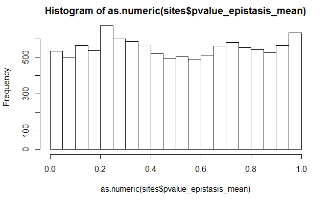

```r
#chosen_one <- sites[sites$node == "INTNODE2429" & sites$depth == 50,] # INTNODE2429 2434 2406
#hist(chosen_one$pvalue_epi_median)
hist(as.numeric(sites$pvalue_epistasis_mean))
#hist(chosen_one$pvalue_epi_mean)
fast_subset <- sites[sites$mutations > 3,]
opar=par(ps=18)
```

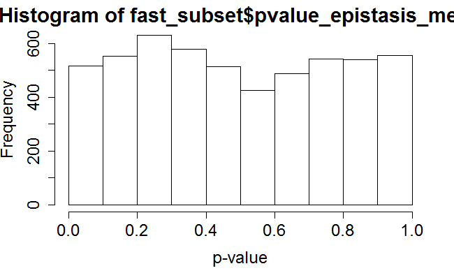

```r
hist(fast_subset$pvalue_epistasis_mean, xlab="p-value")
```

```r
opar
```

```
$ps
[1] 12
```

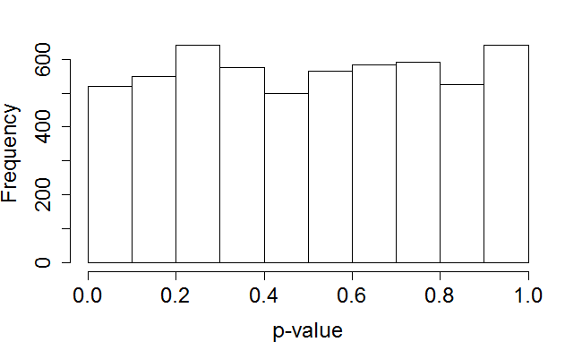

```r
slow_subset <- sites[sites$mutations <= 3,]
hist(slow_subset$pvalue_epistasis_mean, main="", xlab="p-value")
```

```r
all_sites<-read.csv("C:/Users/weidewind/Documents/CMD/Coevolution/Influenza/environment_or_epistasis/sanityCheck/csv_test.txt", stringsAsFactors=FALSE, colClasses = c("pvalue_epistasis_median" = "numeric"))
all_sites[all_sites$site ==85 & all_sites$node =="INTNODE2434",]
```

|  | depth | site | node | mutations | maxlength | pvalue_epistasis_median | pvalue_epistasis_mean | pvalue_environment_median | pvalue_environment_mean | obs_median | exp_median | obs_mean | exp_mean | iterations |
| --- | --- | --- | --- | --- | --- | --- | --- | --- | --- | --- | --- | --- | --- | --- |
| 3 | 100 | 85 | INTNODE2434 | NA | NA | NA | NA | NA | NA | NA | NA | NA | NA | NA |
| 61 | 150 | 85 | INTNODE2434 | 4 | 269 | 0.2642276 | 0.2235772 | 0.7357724 | 0.7764228 | 208.50 | 224 | 187.1250 | 202.59366 | 246 |
| 131 | 50 | 85 | INTNODE2434 | 4 | 269 | 0.2354949 | 0.2013652 | 0.7645051 | 0.7986348 | 208.50 | 224 | 187.1250 | 202.59366 | 293 |
| 3225 | 100 | 85 | INTNODE2434 | 4 | 269 | 0.2633452 | 0.1601423 | 0.7366548 | 0.8398577 | 212.25 | 225 | 182.1250 | 205.21245 | 281 |
| 3247 | 150 | 85 | INTNODE2434 | 4 | 269 | 0.2804878 | 0.1788618 | 0.7195122 | 0.8211382 | 212.25 | 225 | 182.1250 | 205.21245 | 246 |
| 3288 | 50 | 85 | INTNODE2434 | 4 | 269 | 0.2525597 | 0.1535836 | 0.7474403 | 0.8464164 | 212.25 | 225 | 182.1250 | 205.21245 | 293 |
| 4096 | 100 | 85 | INTNODE2434 | 3 | 269 | 0.6387097 | 0.4193548 | 0.3774194 | 0.5806452 | 244.00 | 225 | 206.5000 | 202.03014 | 310 |
| 4119 | 150 | 85 | INTNODE2434 | 3 | 269 | 0.6017316 | 0.4155844 | 0.4199134 | 0.5844156 | 244.00 | 225 | 206.5000 | 202.03014 | 231 |
| 4145 | 50 | 85 | INTNODE2434 | 3 | 269 | 0.6495468 | 0.4320242 | 0.3655589 | 0.5679758 | 244.00 | 225 | 206.5000 | 202.03014 | 331 |
| 5166 | 100 | 85 | INTNODE2434 | 4 | 269 | 0.2597865 | 0.4128114 | 0.7437722 | 0.5871886 | 211.50 | 225 | 205.8750 | 201.98646 | 281 |

[output cut: 16 more lines]